# Lab 2

## Exercise 3

There is a data set called `iris` in the MASS R package. Load the MASS library and the iris data. Use `?iris` to view the documentation for the data set.

1. Create four boxplots showing `Sepal.Length`, `Sepal.Width`, `Petal.Length`, `Petal.Width`grouped by `Species`. Use `par(mfrow)` to display them with a single plot with four panels.

**Answer:**

```r
# Loading dataset
library(MASS)
data(iris)
head(iris)
```

```
##   Sepal.Length Sepal.Width Petal.Length Petal.Width Species
## 1          5.1         3.5          1.4         0.2  setosa
## 2          4.9         3.0          1.4         0.2  setosa
## 3          4.7         3.2          1.3         0.2  setosa
## 4          4.6         3.1          1.5         0.2  setosa
## 5          5.0         3.6          1.4         0.2  setosa
## 6          5.4         3.9          1.7         0.4  setosa
```

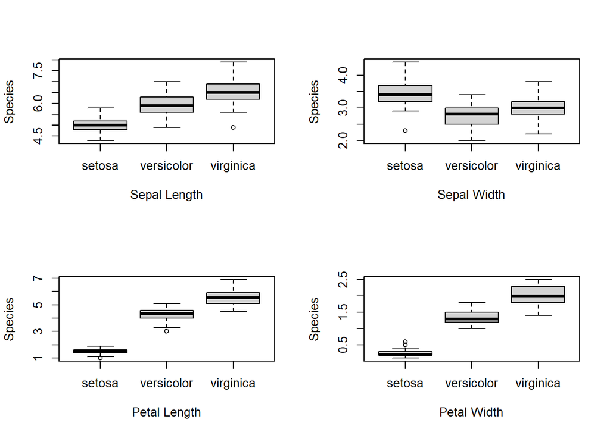

```r
# Creating boxplots

par(mfrow=c(2,2))
boxplot(iris$Sepal.Length ~ iris$Species, xlab = 'Sepal Length', ylab = "Species")
boxplot(iris$Sepal.Width ~ iris$Species, xlab = 'Sepal Width', ylab = "Species")
boxplot(iris$Petal.Length ~ iris$Species, xlab = 'Petal Length', ylab = "Species")
boxplot(iris$Petal.Width ~ iris$Species, xlab = 'Petal Width', ylab = "Species")
```

2. Suppose you were given these measurements of an iris at random: `Sepal.Length`=6, `Sepal.Width`=2.7, `Petal.Length`=6, `Petal.Width`=1.6. Which species do you think it would belong to? Are any of its measurements surprising?

**Answer: Likely versicolor species due to Sepal Length and Sepal Width.**

3. Use some plots and summary statistics to continue exploring the data. Propose a simple rule for classifying iris species based on their petal and sepal measurements. (Your rule might look something like this: if petal.width > 5 and 2< sepal.width < 4, classify as “virginica”)

**Answer: IF petal.length < 2 AND petal.width < 1: Setosa. ELIF 2 < petal.length < 4.7 AND 1 < petal.width < 1.7: Versicolor. ELSE Virginica.**